# IE 423 Project Part 1

Baran Kırkgöz & Orkan Çelikhisar

2023-10-31

## Introduction

In this project, we aim to analyze 6 stocks of Borsa Istanbul and detect outliers by using Boxplot and 3-sigma limits. After this step, we compared each stock with relevant google trends data. For google trends, we used the names of the companie, eg. for MGROS stock data we used “Migros” search volume.

## Identification of Outliers

First necesssary packages and libraries are installed.

There are some errors but it is ok.

Now the data is retrieved.

```r
data <- read_csv("all_ticks_wide.csv.gz")
```

Let’s organize the data in choronological order and select 6 sample stock.

Banking: Akbank, Is Bankası / Retail: Migros, Arçelik / Energy: Aygaz, Tüpraş

```r
data <- data %>% arrange(timestamp)
selected_stocks <- c("AKBNK", "ISCTR", "MGROS", "ARCLK", "AYGAZ", "TUPRS")
```

Filter the data for the selected stocks and for a duration of at least 2 years

```r
data_filtered <- data %>%
  select(all_of(c("timestamp", selected_stocks)))
```

Realize that working with the long format is easier Totally forget the fact that the data was given to us in both formats Ask ChatGPT how to transform stock data from wide format to long format Convert data to long format

```r
data_long <- data_filtered %>%
  pivot_longer(cols = -timestamp, names_to = "name", values_to = "value")
```

It seems that in the dataset there’s a 0.0001 value for every stock at the exact same timestamp This is most probably a placeholder To be able to conduct an accurate analysis, we have removed the rows with the values 0.0001

```r
data_long <- data_long %>%
  filter(value != 0.0001)
```

Identification of Outliers using Boxplots and 3-Sigma Limits: Generate boxplots for the chosen indices

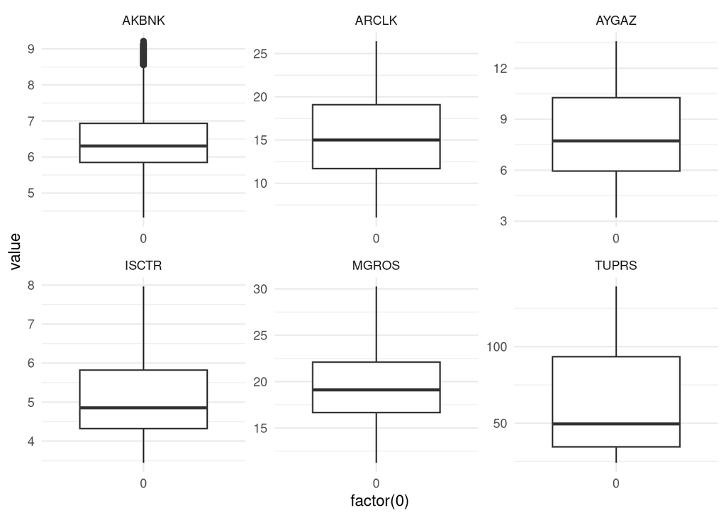

```r
p <- ggplot(data_long, aes(x = factor(0), y = value)) +
  geom_boxplot() +
  facet_wrap(~name, scales = "free") +
  theme_minimal()

print(p)
```

# 3-Sigma rule

```r
outliers <- data_long %>%
  group_by(name) %>%
  mutate(month = format(timestamp, "%Y-%m"),
         mean_price = mean(value, na.rm = TRUE),
         sd_price = sd(value, na.rm = TRUE),
         lower_limit = mean_price - 3 * sd_price,
         upper_limit = mean_price + 3 * sd_price) %>%
  filter(value < lower_limit | value > upper_limit)

print(outliers)
```

```
## # A tibble: 0 × 8
## # Groups:   name [0]
## # ℹ 8 variables: timestamp <dttm>, name <chr>, value <dbl>, month <chr>,
## #   mean_price <dbl>, sd_price <dbl>, lower_limit <dbl>, upper_limit <dbl>
```

After removing the 0.0001 placeholders, according to the 3-Sigma rule there are no outliers. Let’s try the 3-Sigma rule for monthly variations now in order to achieve a higher sensitivity.

# 3-Sigma rule for monthly variations

```r
outliers <- data_long %>%
  group_by(name, month = format(timestamp, "%Y-%m")) %>%
  mutate(mean_price = mean(value, na.rm = TRUE),
         sd_price = sd(value, na.rm = TRUE),
         lower_limit = mean_price - 3 * sd_price,
         upper_limit = mean_price + 3 * sd_price) %>%
  filter(value < lower_limit | value > upper_limit)

outliers
```

```
## # A tibble: 434 × 8
## # Groups:   name, month [73]
##    timestamp           name  value month   mean_price sd_price lower_limit
##    <dttm>              <chr> <dbl> <chr>        <dbl>    <dbl>       <dbl>
##  1 2012-10-04 09:15:00 MGROS 18.4  2012-10      19.1     0.232       18.4
##  2 2012-10-04 11:00:00 MGROS 18.4  2012-10      19.1     0.232       18.4
##  3 2012-11-01 07:45:00 ARCLK  7.67 2012-11       7.06    0.201        6.46
##  4 2012-11-01 08:00:00 ARCLK  7.71 2012-11       7.06    0.201        6.46
##  5 2012-11-01 08:30:00 ARCLK  7.71 2012-11       7.06    0.201        6.46
##  6 2012-11-01 08:45:00 ARCLK  7.67 2012-11       7.06    0.201        6.46
##  7 2012-11-01 09:45:00 ARCLK  7.74 2012-11       7.06    0.201        6.46
##  8 2012-11-01 10:00:00 ARCLK  7.74 2012-11       7.06    0.201        6.46
##  9 2012-11-01 10:15:00 ARCLK  7.74 2012-11       7.06    0.201        6.46
## 10 2012-11-01 12:00:00 ARCLK  7.74 2012-11       7.06    0.201        6.46
## # ℹ 424 more rows
## # ℹ 1 more variable: upper_limit <dbl>
```

Convert the timestamp to date and then create a 6-monthly grouping variable

```r
data_long <- data_long %>%
  mutate(date = as.Date(timestamp),
         six_month_period = ifelse(month(date) %in% 1:6, paste(year(date), "H1", sep="-"), paste(year(date), "H2", sep="-")))
```

# 3-Sigma rule for 6-monthly variations

```r
outliers_6months <- data_long %>%
  group_by(name, six_month_period) %>%
  mutate(mean_price = mean(value, na.rm = TRUE),
         sd_price = sd(value, na.rm = TRUE),
         lower_limit = mean_price - 3 * sd_price,
         upper_limit = mean_price + 3 * sd_price) %>%
  filter(value < lower_limit | value > upper_limit)

outliers_6months
```

```
## # A tibble: 216 × 9
## # Groups:   name, six_month_period [17]
##    timestamp           name  value date       six_month_period mean_price
##    <dttm>              <chr> <dbl> <date>     <chr>                 <dbl>
##  1 2012-12-10 15:00:00 MGROS  23.2 2012-12-10 2012-H2                19.8
##  2 2012-12-13 07:45:00 MGROS  24.4 2012-12-13 2012-H2                19.8
##  3 2012-12-13 08:00:00 MGROS  23.5 2012-12-13 2012-H2                19.8
##  4 2013-06-24 13:15:00 MGROS  17.7 2013-06-24 2013-H1                22.3
##  5 2013-06-24 13:30:00 MGROS  17.6 2013-06-24 2013-H1                22.3
##  6 2013-06-24 13:45:00 MGROS  17.6 2013-06-24 2013-H1                22.3
##  7 2013-06-24 14:00:00 MGROS  17.6 2013-06-24 2013-H1                22.3
##  8 2013-06-24 14:15:00 MGROS  17.4 2013-06-24 2013-H1                22.3
##  9 2013-06-24 14:30:00 MGROS  17.5 2013-06-24 2013-H1                22.3
## 10 2013-06-25 06:30:00 MGROS  17.7 2013-06-25 2013-H1                22.3
## # ℹ 206 more rows
## # ℹ 3 more variables: sd_price <dbl>, lower_limit <dbl>, upper_limit <dbl>
```

Now there are much less outliers but still not a very small amount

I personally was interested to see the effect of the total IT Malfunction of Akbank on July 2021, though it seems the dataset is not up-to-date.

# Google Trends Data

Now to investigate the relationship between stocks and search volume of the related words the google trends data will be analyzed for each of the selected stock. The google trends data and the stock data will be analyzed to understand whether there is a correlation between them.

## Akbank

To understand Akbank stock data, the keyword “Akbank” is selected for the years between 2012-2019. As it can be seen from the two graphs, there is no significant relationship between the trend of AKBNK stock and Akbank search volume on google.

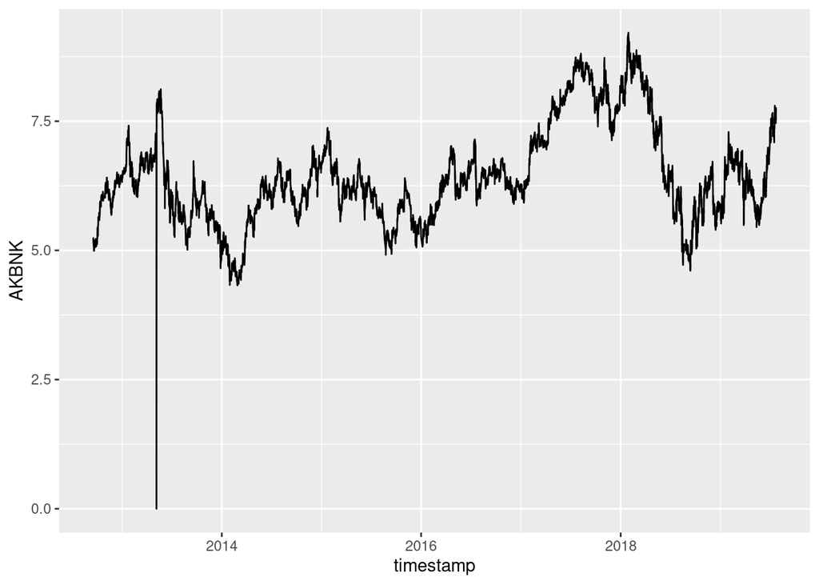

```r
g <- ggplot(data_filtered, aes(x=timestamp, y=AKBNK)) +
  geom_line()
g
```

```r
AKBNK_data <- read_csv("multiTimeline (4).csv")
```

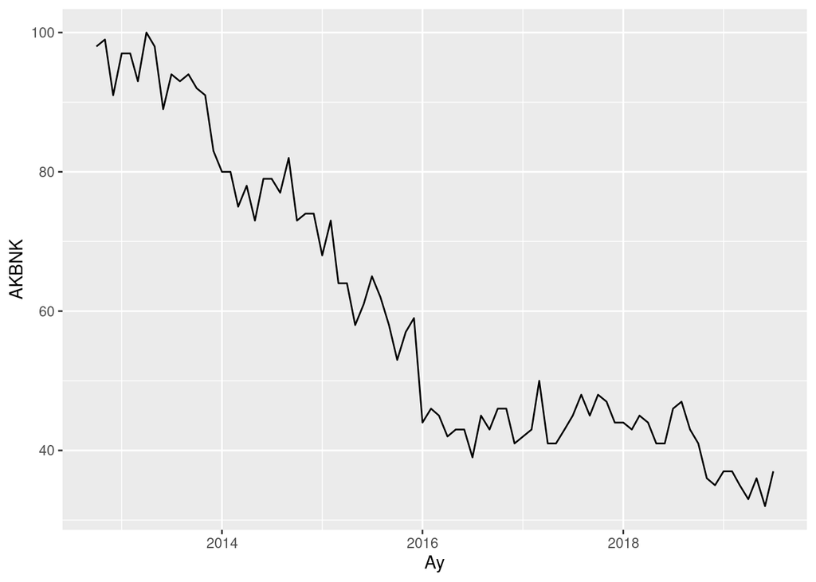

```r
AKBNK_data$Ay<- ym(AKBNK_data$Ay)
a <- ggplot(AKBNK_data, aes(x=Ay, y=AKBNK)) +
  geom_line()
a
```

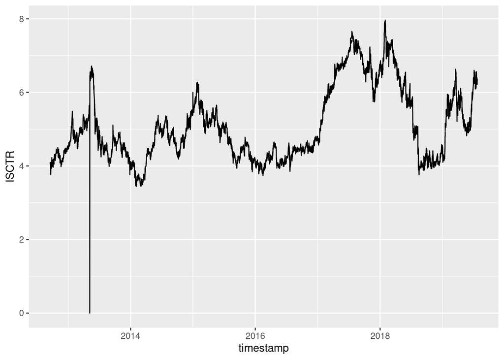

```r
x <- ggplot(data_filtered, aes(x=timestamp, y=ISCTR)) +
  geom_line()
x
```

## ISCTR Data

```r
ISCTR_data <- read_csv("multiTimeline (5).csv")
```

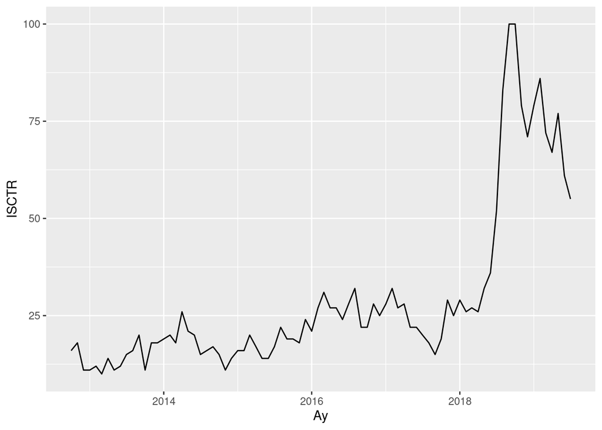

```r
ISCTR_data$Ay<- ym(ISCTR_data$Ay)
ISCTRgraph <- ggplot(ISCTR_data, aes(x=Ay, y=ISCTR)) +
  geom_line()
ISCTRgraph
```

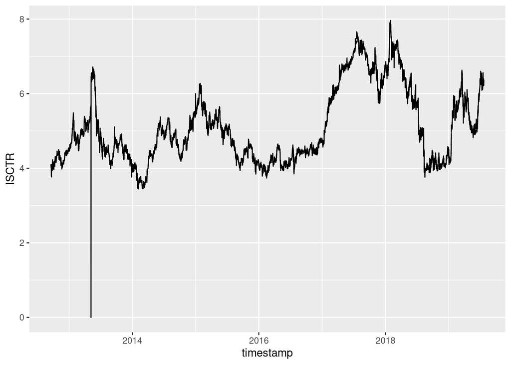

```r
y <- ggplot(data_filtered, aes(x=timestamp, y=ISCTR)) +
  geom_line()
y
```

## MGROS

```r
MGROS_data <- read_csv("multiTimeline (6).csv")
```

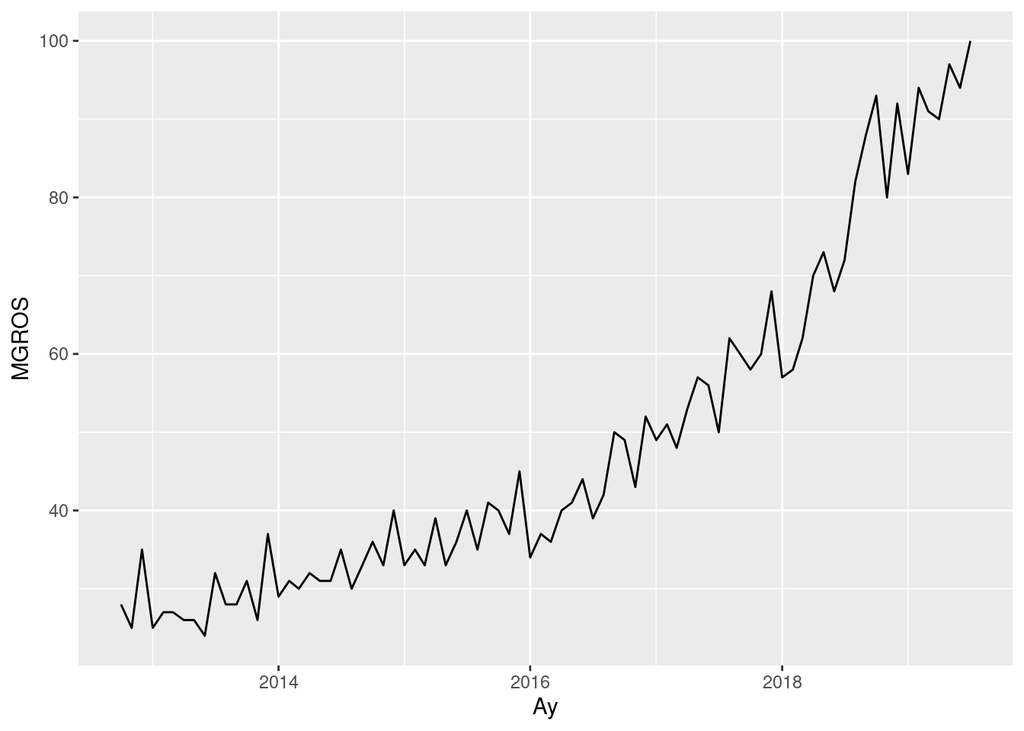

```r
MGROS_data$Ay<- ym(MGROS_data$Ay)
MGROSgraph <- ggplot(MGROS_data, aes(x=Ay, y=MGROS)) +
  geom_line()
MGROSgraph
```

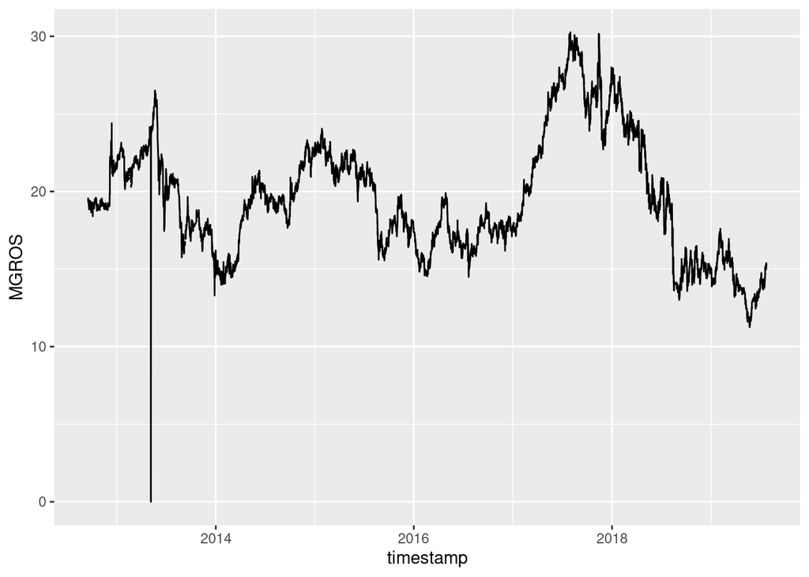

```r
l <- ggplot(data_filtered, aes(x=timestamp, y=MGROS)) +
  geom_line()
l
```

## ARCLK

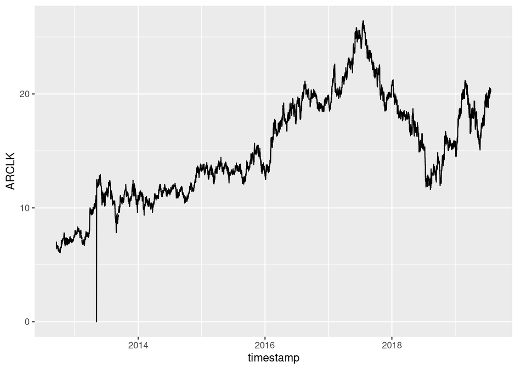

```r
k <- ggplot(data_filtered, aes(x=timestamp, y=ARCLK)) +
  geom_line()
k
```

```r
ARCLK_data <- read_csv("multiTimeline (7).csv")
```

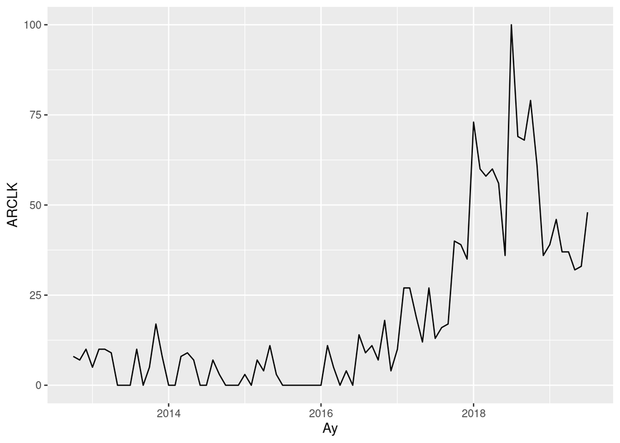

```r
ARCLK_data$Ay<- ym(ARCLK_data$Ay)
ARCLKgraph <- ggplot(ARCLK_data, aes(x=Ay, y=ARCLK)) +
  geom_line()
ARCLKgraph
```

## AYGAZ

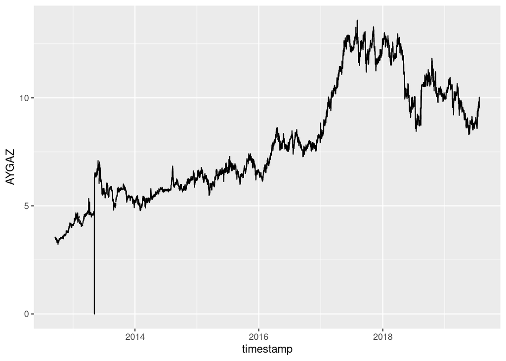

```r
m <- ggplot(data_filtered, aes(x=timestamp, y=AYGAZ)) +
  geom_line()
m
```

```r
AYGAZ_data <- read_csv("multiTimeline (8).csv")
```

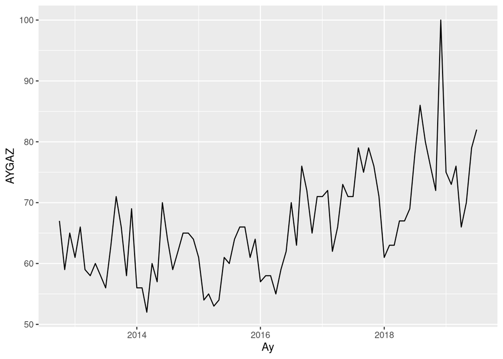

```r
AYGAZ_data$Ay<- ym(AYGAZ_data$Ay)
AYGAZgraph <- ggplot(AYGAZ_data, aes(x=Ay, y=AYGAZ)) +
  geom_line()
AYGAZgraph
```

## TUPRS

The two graphs are very similar after 2016, both of them start to increase with varience.

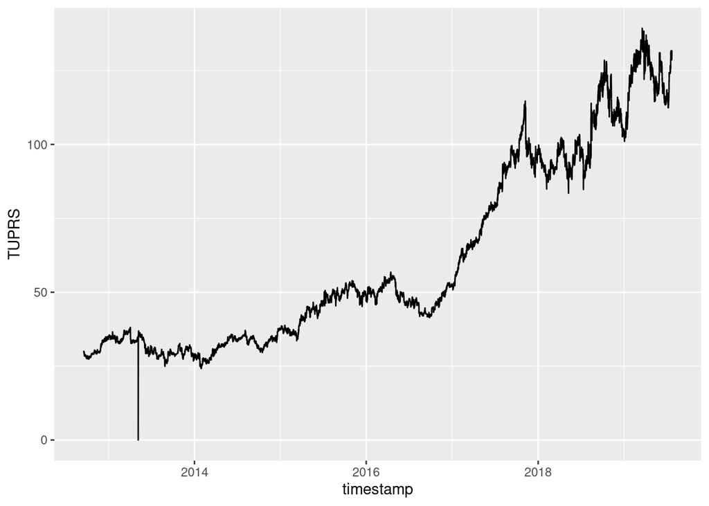

```r
n <- ggplot(data_filtered, aes(x=timestamp, y=TUPRS)) +
  geom_line()
n
```

```r
TUPRS_data <- read_csv("multiTimeline (9).csv")
```

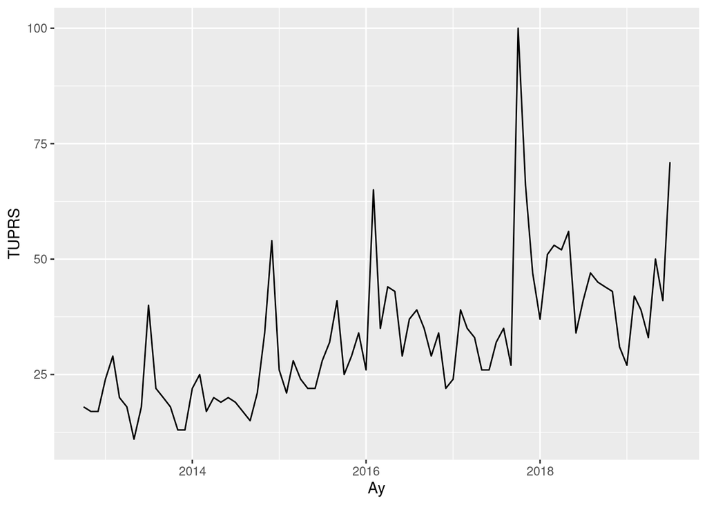

```r
TUPRS_data$Ay<- ym(TUPRS_data$Ay)
TUPRSgraph <- ggplot(TUPRS_data, aes(x=Ay, y=TUPRS)) +
  geom_line()
TUPRSgraph
```